# Heights Impact On Tennis Players

Name: Michael Napolitano

# Motivation

In tennis tall players are sterotypically considered big servers and bad returners. When I hear it mentioned though by commentators I rarely hear any statistics or data but just their observations. I want to find out if there really is a relation between height with both serving and returning statistics. When you think of the great servers the names that come to mind are John Isner, Karlovic, who are considered tall for tennis players, but you also think of players like Pete Sampras and Rodger Federer who are not especially tall for professional tennis players. This leads me to question whether there is a real relation between height and serving in professioal tennis or whether it is an old sterotype of tennis that is still around, based on observation and not data. I don't only want to answer whether they are bigger serves, as in they can serve it faster, but if they are more effective servers, do they win more service points then other player. There is also the idea in tennis that tall players are not as good at returning. There are examples on both sides of this that I can thinks of as well. Like John Isner is tall and not a very good returner, but on the other hand Del Potro was a tall player and a good returner. Once again I want to see if there is any statistical evidence for these claims. These observations in themselves are not evidence for or against the claim, but they did spark my interest to look deeper into this idea. Then if there is a relation between both serving and returning with height, I want to see whether it is a good trade off or a bad tradeoff by seeing what the relation with height and win rate is. This would be good to know when deciding who to look at for tennis prospects. It would be important to know for tennis coaches to know the effect height has on a players ability to both serve and return as well as win. It is also important to look at the data in sports and not get distracted by the flare of a player. Some one may have a big serve, and watching him would be impressive, but that doesn't mean they win service point more often. I feel that it is very common to make judgements on sport based on appearance and not on data, and that is why I want to take a data driven players serving abilities versus their height.  
Players Bios for players mentioned above:  
Federer: https://www.atptour.com/en/players/roger-federer/f324/overview  
Sampras: https://www.atptour.com/en/players/pete-sampras/s402/overview  
Isner: https://www.atptour.com/en/players/john-isner/i186/overview  
Karlovic: https://www.atptour.com/en/players/ivo-karlovic/k336/overview  
Del Potro: https://www.atptour.com/en/players/juan-martin-del-potro/d683/overview

# Background

I want to go over some of the basics of tennis first so you will be able to better understand what I am going to be talking about. If you want a more in depth look at the rules of tennis you can look here http://protennistips.net/tennis-rules/. If you want to learn more about tennis in general and playing tennis you can look at the USTA site here https://www.usta.com/. Now I will go over a brief summary of things I think you should know to understancd what I am talking about. First if you could look at this diagram of a court so you will know the terminology https://tenniscompanion.org/a-diagram-of-tennis-court-dimensions-layout/. A tennis match consists either of a best of 3 or 5 sets. A set consists of best of 6 games win by 2, but if you get to 6 all you play a tie break. For each game you have one player serving and one returning. A game is first to four points win by 2. Players alternate serve each game. A serve is the shot that starts a point where one player standing behing the baseline hits it into diagonal service box of the opponent. You get two serves in tennis, so if the 1st serve goes out you have one more chance before losing a point. If they miss the second serve then they lose a point. After each serve players switch which service box is being served to.

Terminology:  
Double Fault: If you hit 1st and 2nd serve out that is called a double fault  
Ace: If the server hit his serve in and it goes untouched by the returner  
Break Point: If the returner is one point from winning the game  
Service Box: Section of the court the serve must land in  
Baseline: Is the boundary line that is parallel to the net. Hold: When server wins the game Break: When returner win the game

# Getting the Data

Though out this tutorial I will be using the pandas and numpy libraries to store and manipulate the data. Pandas is very useful whenever using table data, and numpy is very useful for math operations on arrays. If you want to learn more about these libraries you can visit these links below  
Pandas: https://pandas.pydata.org/docs/index.html  
Numpy: https://numpy.org/doc/stable/user/index.html#user

```python
import pandas as pd
import numpy as np
import statsmodels.api as stats
from matplotlib import pyplot as plt
import csv
import warnings
warnings.filterwarnings('ignore')
# null values were causing warnings before filled
```

```python
# Import data from https://github.com/JeffSackmann/tennis_atp first.
data2015 = pd.read_csv('data/atp_matches_2015.csv')
data2016 = pd.read_csv('data/atp_matches_2016.csv')
data2017 = pd.read_csv('data/atp_matches_2017.csv')
data2018 = pd.read_csv('data/atp_matches_2018.csv')
data2019 = pd.read_csv('data/atp_matches_2019.csv')
data2020 = pd.read_csv('data/atp_matches_2020.csv')
data2021 = pd.read_csv('data/atp_matches_2021.csv')
data = pd.concat([data2015,data2016,data2017,data2019,data2020,data2021])
```

The tour level match data that we are looking at includes Davis cup, which is not part of the ATP tour technically so I do not want to look at matches from that, so I removed them.

After removing all of the Davis cup matches I will then extract the serving and returning data columns I need, to calculate the statistics wanted, as well as height and player names. There are alot of other columns I don't need in the data, like information about the tournament or the player, this will be removed to make it simpler.

```python
data = data[data['tourney_level'] != 'D']
data = data[['w_1stIn','w_1stWon','l_1stIn', 'l_1stWon','winner_name','loser_name','loser_ht','w_ace','w_svpt','winner_ht',
             'w_2ndWon','w_bpFaced','w_bpSaved','l_ace','l_2ndWon','l_bpSaved','l_bpFaced','l_svpt']]
```

Now that I have loaded in the data I will first take a quick look at it to show what the data I'm dealing with looks like. Then I will look for missing data and try to fill it in by either finding the information somewhere else or coming up with a imputation method to fill it in.

```python
data.head()
```

|  | w_1stIn | w_1stWon | l_1stIn | l_1stWon | winner_name | loser_name | loser_ht | w_ace | w_svpt | winner_ht | w_2ndWon | w_bpFaced | w_bpSaved | l_ace | l_2ndWon | l_bpSaved | l_bpFaced | l_svpt |
| --- | --- | --- | --- | --- | --- | --- | --- | --- | --- | --- | --- | --- | --- | --- | --- | --- | --- | --- |
| 0 | 24.0 | 19.0 | 31.0 | 20.0 | John Millman | Rhyne Williams | NaN | 6.0 | 44.0 | 183.0 | 14.0 | 1.0 | 1.0 | 3.0 | 5.0 | 1.0 | 5.0 | 50.0 |
| 1 | 59.0 | 39.0 | 50.0 | 26.0 | Jarkko Nieminen | Denis Kudla | 180.0 | 4.0 | 92.0 | 185.0 | 17.0 | 7.0 | 4.0 | 6.0 | 19.0 | 3.0 | 8.0 | 83.0 |
| 2 | 27.0 | 20.0 | 37.0 | 22.0 | James Duckworth | Gilles Simon | 183.0 | 4.0 | 45.0 | 183.0 | 11.0 | 3.0 | 2.0 | 2.0 | 5.0 | 10.0 | 15.0 | 56.0 |
| 3 | 39.0 | 31.0 | 38.0 | 30.0 | Jeremy Chardy | Andrey Golubev | 185.0 | 7.0 | 53.0 | 188.0 | 11.0 | 0.0 | 0.0 | 9.0 | 8.0 | 1.0 | 3.0 | 57.0 |
| 4 | 79.0 | 55.0 | 62.0 | 40.0 | Martin Klizan | Jurgen Melzer | 183.0 | 9.0 | 130.0 | 190.0 | 27.0 | 8.0 | 6.0 | 4.0 | 19.0 | 4.0 | 8.0 | 95.0 |

# Missing Data

Now I am going to clean up the data and fill in any missing values.

First I will just look to see what columns have missing data in it so I know what parts of the table I need to look deeper into. I will then find ways to fill in any missing data.

```python
for column in data.columns:
    if len(data[data[column].isna() == True]) != 0 :
        print(column)
```

```
w_1stIn
w_1stWon
l_1stIn
l_1stWon
loser_ht
w_ace
w_svpt
winner_ht
w_2ndWon
w_bpFaced
w_bpSaved
l_ace
l_2ndWon
l_bpSaved
l_bpFaced
l_svpt
```

## Finding Heights with External Data

It seems that all of the columns have some amount of missing data. First part of the missing data I will address is the heights of the players since that is one of the main features of the players I am focusing on. To do this I will need to collect more data from an another source. Luckly https://www.atptour.com/ gives the heights of all the players that play on tour, so I will write all the names down with missing heights into a csv file and then manually enter in the height data for each player. Then I can load in the data back into pandas and enter it into the data. One player I did not find the heigth of on atptour was Flavio Cobolli, who I had to find a seperate bio to fill in his height data, you can find this with a simple google search of the player. I started off by doing this for missing winner heights and then loser heights assuming there will be cross over and this will stop names from being printed twice. When I did this there was 140 players whose heights needed to be filled in for the winners alone. I have put the csv file PlayersNames.csv in the repository here https://github.com/RomanMaximus/RomanMaximus.github.io/blob/main/PlayerNames.csv, incase you want to repeat what I have done, so you do not have to enter in all that data yourself.

```python
file = open('PlayerNames.csv','w')
writer = csv.writer(file)
# writing all the names into a csv so I can fill in heights myself
for name in np.unique(data[data['winner_ht'].isna() == True]['winner_name']):
    writer.writerow([name])
file.close()
```

[output not shown]

While going through the names to add in the height I found one mistake where Alejandro Gomez was named as Alejandro Gomez Gb42. I have verified that these are refering to the same player and that Alejandro Gomez Gb42 is not another player.

```python
# Name was put in wrong on some entries, I did verify these were refering to the same man
data.loc[data['winner_name'] == 'Alejandro Gomez Gb42','winner_name'] = 'Alejandro Gomez'
data.loc[data['loser_name'] == 'Alejandro Gomez Gb42','loser_name'] = 'Alejandro Gomez'
```

Now I found the heights and updated the PlayersName.csv file manually and saved it. Now I can read the csv file in and will in the data frame with the information found.

```python
heights = pd.read_csv('PlayerNames.csv')
# read in the csv after changing it manually outside of notebook
# fill in players height for each instance their name shows up
for name in np.unique(data[data['winner_ht'].isna() == True]['winner_name']):
    data.loc[data['winner_name'] == name, 'winner_ht'] = int(heights.loc[heights['Name'] == name,'HT'])
    data.loc[data['loser_name'] == name, 'loser_ht'] = int(heights.loc[heights['Name'] == name,'HT'])
```

Now I will do the same process with a new file for the loser heights that are missing.

```python
file2 = open('PlayerNames2.csv','w')
writer = csv.writer(file2)
for name in np.unique(data[data['loser_ht'].isna() == True]['loser_name']):
    writer.writerow([name])
file2.close()
```

For the players that I could not find there height reported on the atp tour site or anywhere else I filled in the average losing height, since this is the list of losing players missing height and any that won would have been filled in earlier, as my imputation technique. The 8 players below were the only 8 I could not find anything on. I decided to round the average since the rest of the players heights were reported as integers and not decimals. For the rest I used the atp site again to find their height or for some a google search. There was another 123 players to have their hieghts filled. Once again the csv file with there heights is here, https://github.com/RomanMaximus/RomanMaximus.github.io/blob/main/PlayerNames2.csv, if you wish to run this yourself.

```python
#Below are the players I could not find heights for in other sources
#so filling in with average heights
avgHt = round(np.average(np.array(data[data['loser_ht'].isna() == False]['loser_ht'])))
data.loc[data['loser_name'] == 'Adrien Bossel', 'loser_ht'] = avgHt
data.loc[data['loser_name'] == 'Alexios Halebian', 'loser_ht'] = avgHt
data.loc[data['loser_name'] == 'Anil Yuksel','loser_ht'] = avgHt
data.loc[data['loser_name'] == 'Brian Shi','loser_ht'] = avgHt
data.loc[data['loser_name'] == 'Mubarak Shannan Zayid','loser_ht'] = avgHt
data.loc[data['loser_name'] == 'Riccardo Bellotti','loser_ht'] = avgHt
data.loc[data['loser_name'] == 'Yassine Idmbarek','loser_ht'] = avgHt
data.loc[data['loser_name'] == 'Omar Awadhy','loser_ht'] = avgHt
```

Once again I have updated the final externally adding the new heights. Now I can load it in an update the data. The updated file is linked above if you wish to use the data without having to find it all yourself.

```python
heights = pd.read_csv('PlayerNames2.csv')
#read in file that was updated externally
#update data with players heights
for name in np.unique(data[data['loser_ht'].isna() == True]['loser_name']):
    data.loc[data['loser_name'] == name, 'loser_ht'] = int(heights.loc[heights['Name'] == name,'HT'])
```

## Data Imputation For Remaining Missing Data

Now I am going to fill in the missing data for the rest of the columns. These columns consist of 1st serve in for both winners and losers,1st serve won for both, aces, 2nd serves won, number of service points, break points faced and saved. The way I am going to do this is, for each player that is missing a value in one of these categories, I will calculate their average value of the statistic for when they lose and win respectively and then fill the missing value in as the average for that player. I choose to round the average since a decimal doesnt make sense as an entry for these statistics only a whole number would make sense.

```python
# use column names to iterate through and not need to repeat code
columnNames = ['1stIn','1stWon','ace','svpt','bpFaced','bpSaved','2ndWon']
for col in columnNames:
    #fills in missing winner data
    for name in np.unique(data[data['w_'+col].isna() == True]['winner_name']):
        #get data of player thats not missing
        playerdata = data[data['winner_name'] == name]
        playerdata = playerdata[playerdata['w_'+col].isna() == False]
        #caculate average for that player
        avg = np.average(playerdata['w_'+col])
        #fill in missing data for each player with their average
        data.loc[(data['winner_name'] == name) & (data['w_'+col].isna()==True),'w_'+col] = np.round(avg)

    #fills in missing loser data
    for name in np.unique(data[data['l_'+col].isna() == True]['loser_name']):
        #get data for player that is not empty
        playerdata = data[data['loser_name'] == name]
        playerdata = playerdata[playerdata['l_'+col].isna() == False]
        #caculate the avg
        avg = np.average(playerdata['l_'+col])
        #fill in missing data for player with his average
        data.loc[(data['loser_name'] == name) & (data['l_'+col].isna()==True),'l_'+col] = np.round(avg)
```

Now lets make sure the data was filled in or if their is still more work to be done.

```python
for column in data.columns:
    if len(data[data[column].isna() == True]) != 0 :
        print(column)
        print(len(data[data[column].isna() == True]))
```

```
l_1stIn
1
l_1stWon
1
l_ace
1
l_2ndWon
1
l_bpSaved
1
l_bpFaced
1
l_svpt
1
```

As seen above there is missing data in all of the columns associated with the loser and only 1 missing value each. In fact they were all refering to the same observation. I chose to just remove this oberservation from the table because all of the information was missing for that match, and for the losing player it was his only appearance in all of the data. Instead of having a match of completely estimated data I thought it best to just remove this one match. Since all the data was missing other than the names I thought it would be better to remove it since your not really losing any extra data other then the names.

```python
#removing the one match mentioned above
data = data[data['l_1stIn'].isna() == False]
```

Now I want to make sure the matches recorded actually had both players serving. Since some matches get canceled due to injury or disqualification could still be recorded. If they end in the first game then only one player will have served and very few data will be recorded for that.

```python
data[data['w_svpt']==0]
```

|  | w_1stIn | w_1stWon | l_1stIn | l_1stWon | winner_name | loser_name | loser_ht | w_ace | w_svpt | winner_ht | w_2ndWon | w_bpFaced | w_bpSaved | l_ace | l_2ndWon | l_bpSaved | l_bpFaced | l_svpt |
| --- | --- | --- | --- | --- | --- | --- | --- | --- | --- | --- | --- | --- | --- | --- | --- | --- | --- | --- |
| 2612 | 0.0 | 0.0 | 5.0 | 3.0 | Yuichi Sugita | Milos Raonic | 196.0 | 0.0 | 0.0 | 173.0 | 0.0 | 0.0 | 0.0 | 0.0 | 0.0 | 2.0 | 3.0 | 8.0 |

As we can see in the observation above there is one match where the winner didn't serve and points and the loser only served 8. I choose to remove this match from the data because it is not really a match, It must have ended after the first game due to either injury and disqulification. I don't want this skewing the win rate for either player since it was not their abilities that had anything to do with the match and there was not enough of the match to get any useful info out of. If the injury happened in the second set I could see keeping it but since only one game occured I decided to remove it.

```python
data[data['l_svpt']==0]
```

|  | w_1stIn | w_1stWon | l_1stIn | l_1stWon | winner_name | loser_name | loser_ht | w_ace | w_svpt | winner_ht | w_2ndWon | w_bpFaced | w_bpSaved | l_ace | l_2ndWon | l_bpSaved | l_bpFaced | l_svpt |
| --- | --- | --- | --- | --- | --- | --- | --- | --- | --- | --- | --- | --- | --- | --- | --- | --- | --- | --- |

Luckily there is no matches where the loser had no service points so only the one match total had to be removed for not having enough points.

```python
#removing match that only had 8 points
data = data[data['w_svpt']!=0]
```

# Calculate Statistics/Data Analysis

Now that I have filled in all the missing data the table is ready for analysis and make calculations. I will use the data in the table to calculate 7 different statistics for all the players. Four will be service statistics and the other three will be return statistics. I will calculate the first serve percent, which is the percent of first serves that are in. Then I will calculate both the first serve and second serve win percent, which is how many points they are winning of there serves respectively. A double fault,when second serve goes out, will count to losing a second serve point. Finally for serve I will calculate the pertenage of serves that are aces. Now for the return statistics I will calculate the average number of break chances they had per match, when they were one point away from winning a game on return. The break points won percent, of the chances they had how many did they win. For this statistic I decided if they had 0 break point chances then the percent would also be zero, since if they never get a break chance they aren't being very successful at returning so the percent should reflect that. Then just the total percent of return points won. After we look at the individual statistics I will calculate their win percent to look at later. This makes it a total of 8 statistics.

```python
#only want each players name once
players = np.unique(np.append(data['winner_name'],data['loser_name']))
#list for each desired statistic
winrates = []
firstPercents = []
heights = []
firstWRates = []
secWinRate = []
aceRate = []
bpChances = []
bpWinPer = []
winReturnPercents = []

#go through each player and calculate the statistics and append to the
#corresponding list above
for player in players:
    #this adds the heights of all the player to height
    heights.append(int(np.unique(np.append(
        data[data['winner_name']==player]['winner_ht'],data[data['loser_name']==player]['loser_ht']))))
    #this next section calculate the 1st serve percent for each player
    #first seperate the data of when the player wins vs loses
    windata = data[data['winner_name']==player]
    losedata = data[data['loser_name']==player]
    #calculate total matches first this will be used in several calculations
    totalMatches = (len(windata)+len(losedata))
    #find first serves in and then total serve when won
    winServesIn = np.sum(windata['w_1stIn'])
    winServes = np.sum(windata['w_svpt'])
    #if they never won a game need to check if nan
    if winServesIn == np.nan:
        winServesIn = 0
    if winServes == np.nan:
        winServes = 0
    #find first serves in and then total serve when they loss
    loseServesIn = np.sum(losedata['l_1stIn'])
    loseServes = np.sum(losedata['l_svpt'])
    #must check if nan incase player didn't lose a game
    if loseServesIn == np.nan:
        loseServesIn = 0
    if loseServes == np.nan:
        loseServes = 0
    firstPercent = (winServesIn +loseServesIn)/(winServes+loseServes)
    firstPercents.append(firstPercent)

    #Now I am going to calculate the first and second serve win rate.
    firstWon = (np.sum(windata['w_1stWon']) + np.sum(losedata['l_1stWon']))
    firstWRate = firstWon/(winServesIn + loseServesIn)
    firstWRates.append(firstWRate)
    #second serves is total serves - 1st in
    secServes = (winServes - winServesIn) + (loseServes - loseServesIn)
    secWon = (np.sum(windata['w_2ndWon'])+np.sum(losedata['l_2ndWon']))
    secWinPer = secWon/secServes
    secWinRate.append(secWinPer)

    #Now I will calculate the ace rate
    totalAce = (np.sum(windata['w_ace']) + np.sum(losedata['l_ace']))
    totalServes = (winServes + loseServes)
    acePer = totalAce/totalServes
    aceRate.append(acePer)

    #Now will calculate the return stats for players
    #starting with break point chances.
    #break chances would be same as oppents break points faced
    #so I sum that value.
    breakpoints = np.sum(windata['l_bpFaced']) + np.sum(losedata['w_bpFaced'])
    avgbp = breakpoints/totalMatches
    bpChances.append(avgbp)

    #There were some matches with no break points so can't divide by 0
    #Choose to append 0 as percent since if you got no break point chances
    #you weren't returning well so should have a percent to reflect that.
    if breakpoints == 0:
        bpWinPer.append(0)
    else:
        # Break points the player won calculated by the break points not saved by opponent
        bpWon = (breakpoints - (np.sum(windata['l_bpSaved']) + np.sum(losedata['w_bpSaved'])))
        bpPercent = bpWon/breakpoints
        bpWinPer.append(bpPercent)

    #points won on return is calculated by opponents points not won on serve.
    returnPointWon = (np.sum(windata['l_svpt'])-(np.sum(windata['l_1stWon']) + np.sum(windata['l_2ndWon'])))
    returnPointsLoss = (np.sum(losedata['w_svpt'])-(np.sum(losedata['w_1stWon']) + np.sum(losedata['w_2ndWon'])))
    totalReturnPoints = returnPointWon + returnPointsLoss
    totalOpponentServes = (np.sum(windata['l_svpt']) + np.sum(losedata['w_svpt']))
    returnWinPer = totalReturnPoints/totalOpponentServes

    winReturnPercents.append(returnWinPer)

    #Now calculate the win rates
    winrate = len(windata)/totalMatches
    winrates.append(winrate)
```

Now lets put the statisics calculated above together into one dataframe. After that I will print out some of the rows to get an idea of what the data I will be working with looks like.

```python
statsDict = {'heights':heights,'firstPercents':firstPercents,'firstWRates':firstWRates,'secWRates':secWinRate,
                            'aceRate':aceRate,'bpChances':bpChances,'bpWinPer':bpWinPer,'winReturnPercents':winReturnPercents,'WinRate':winrates}
playerStats = pd.DataFrame(statsDict)
```

```python
playerStats.head()
```

|  | heights | firstPercents | firstWRates | secWRates | aceRate | bpChances | bpWinPer | winReturnPercents | WinRate |
| --- | --- | --- | --- | --- | --- | --- | --- | --- | --- |
| 0 | 186 | 0.595765 | 0.691438 | 0.452381 | 0.077960 | 5.666667 | 0.470588 | 0.352128 | 0.333333 |
| 1 | 180 | 0.627863 | 0.604863 | 0.528205 | 0.015267 | 5.714286 | 0.400000 | 0.349693 | 0.285714 |
| 2 | 183 | 0.597473 | 0.701042 | 0.508179 | 0.060059 | 6.731293 | 0.411319 | 0.374549 | 0.479592 |
| 3 | 183 | 0.592225 | 0.689944 | 0.501014 | 0.062862 | 6.200000 | 0.365591 | 0.337500 | 0.266667 |
| 4 | 178 | 0.601190 | 0.599010 | 0.470149 | 0.011905 | 6.250000 | 0.520000 | 0.391437 | 0.250000 |

# Hypothesis

The null hypothesis will be that height has no relation with any of these statistic. The alternate hypothesis will be that there is a relationship between the players height and these statistic. I will be conducting a hypothesis test for each individual statistic. My prediction Is that height will have a relation with first and second serve win rate, ace rate,break point chances, break point win percents, return point win percents. Leaving it not having a relationship with frist serve percent and win rate. I think this because I feel like height doesn't help someone get their serve in more, but allows them to hit it bigger, so when it goes in they are winning more. I also think taller people tend to return worse so it will have a relation their. These predictions are purely based on my observations of watching tennis and just my prior knowledge on the subject. Since there are only a couple hundred players in the atp I will be using a p-val of .05 to deam significance. Since there is only a limited number of players and not that many data points I do not feel there is enough data to choose a smaller p-value.

# Plots

Now lets plot some of these statistics against height just to get a first impression on the data and the relations, before making the regression and checking its p-values.

To make the plots I will be using the pyplot library from matplotlib. If you would like to learn more about this library you can go to the link below. There is alot more you can do with this library then I will be showing. There are many more bult in types of plot then the scatter plots I will be using. There is also ways to change the look of the plot, use different colors, and add keys if you need to. For my plots I did not need these features so please explore the library if you wish to learn more about plotting in python.  
Pyplot: https://matplotlib.org/stable/tutorials/introductory/pyplot.html

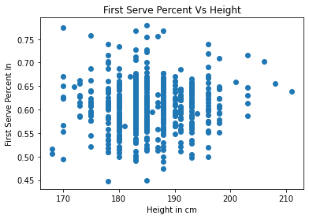

```python
#plotting first plot height vs first serve percent
fig1,ax1 = plt.subplots()
ax1.scatter(playerStats['heights'],playerStats['firstPercents'])
ax1.set_xlabel('Height in cm')
ax1.set_ylabel('First Serve Percent In')
ax1.set_title('First Serve Percent Vs Height')
fig1.show()
```

At first look it seem my prediction will be right, there does't seem to be any real relationship between height and first serve percent. As the player gets taller they seem to have less of a range of serve percent but in both directions. They never really reach the extremes of the average height players on either end. For all heights they seem to be in one main clump of around 50 to 70 percent. On the extreme end of height they seem to be at the upper end of the main clump of points without any in the lower part.

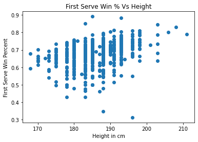

```python
#plotting second plot height vs first serve win percent
fig2,ax2 = plt.subplots()
ax2.scatter(playerStats['heights'],playerStats['firstWRates'])
ax2.set_xlabel('Height in cm')
ax2.set_ylabel('First Serve Win Percent')
ax2.set_title('First Serve Win % Vs Height')
fig2.show()
```

At first look there seem to be a slight postive relation with height and first serve win percent, which also might fit my prediction. Is the relation significantly different to zero I'm not confident. We will check for sure later. if you ignore the few outlier in the average height the main body of points seem to have a linear realtion and increasing with height. I am actually a little suprised the highest win percent for a player is some one around 185 cm or around 6 foot, and not someone around the 200 cm range. It is interesting to note that a mjority of players are winning over 50 percent of their first serves. This should be expected as players are expected to win their service games more often then not.

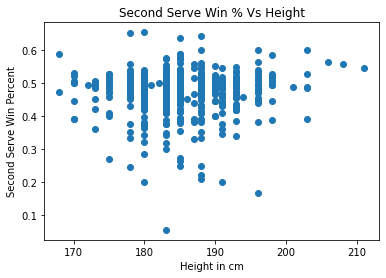

```python
#plotting third plot height vs second serve win percent
fig3,ax3 = plt.subplots()
ax3.scatter(playerStats['heights'],playerStats['secWRates'])
ax3.set_xlabel('Height in cm')
ax3.set_ylabel('Second Serve Win Percent')
ax3.set_title('Second Serve Win % Vs Height')
fig3.show()
```

This is the first plot to really suprise me. There seems to be no relation between height and second serve win percentage. I was suprised to see this because while watching tennis the taller players always seem to have a good second serve that still starts them in the advantage on the point, while shorter players seem to either be at a disadvantage or neutral on the second serve. But this is one of those cases where things as they appear in sports are not supported by the data. Throughout all heights the range of around 43% and 53% win rate seem to contain the majority of players.The only sign I can see on hear that could suggest that tall players have a better second serve is there seems to be a cut off in height for having outliers to the downside. Up until 200 cm in height there is one or two players per height that are way lower than the majority of players for that height. While for players over 200 cm have no one that has a second serve win percent lower than 40%. It is also interesting to note the shift down from first serve win percent above. While on first serves a majority of the players were winning over 50%, for second serves it has switched and a majority is winning under 50%. Actually 50% is close to the upper end for second serve win percent, which makes it seem like the server is no longer in the advantage on second serve for most players.

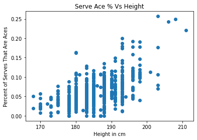

```python
#plotting 4th plot height vs ace rate
fig4,ax4 = plt.subplots()
ax4.scatter(playerStats['heights'],playerStats['aceRate'])
ax4.set_xlabel('Height in cm')
ax4.set_ylabel('Percent of Serves That Are Aces')
ax4.set_title('Serve Ace % Vs Height')
fig4.show()
```

This is the first plot that seems to have a strong positive relation with height. It seems that ace percent and height have a linear relationship as well. This suggest that taller player have bigger serves since more of their serves are untouched by their opponents. We can see that the tallest players have an ace rate of around 25%, which is crazy. That means on their serve they are winning 1/4 of the points with only one stroke, the serve. This gives them an advantage because they are winning alot of "free points", meaning they don't actually have to ralley with their opponent, and are probably conserving energy by only hitting one shot.

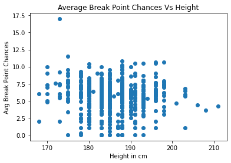

```python
# plotting 5th plot height vs avg break point chances
fig5,ax5 = plt.subplots()
ax5.scatter(playerStats['heights'],playerStats['bpChances'])
ax5.set_xlabel('Height in cm')
ax5.set_ylabel('Avg Break Point Chances')
ax5.set_title('Average Break Point Chances Vs Height')
fig5.show()
```

Once again here is another plot that looks like no relation where I expected there to be one. This is suprising to me because tall players are stereotipically seen as worse returns, but on average they seem to be getting just as many break point chances as the rest of the player field. I guess on the absolute extreme end of height, the tallest players are a little below average on break point chances, but I don't think this is enough to make a significant relation.

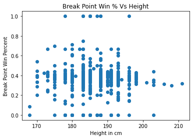

```python
#plotting 6th plot height vs break point win percent
fig6,ax6 = plt.subplots()
ax6.scatter(playerStats['heights'],playerStats['bpWinPer'])
ax6.set_xlabel('Height in cm')
ax6.set_ylabel('Break Point Win Percent')
ax6.set_title('Break Point Win % Vs Height')
fig6.show()
```

Similar to the last plot there seem to be no relation between the height of the player and the capitilization of break points by actually winning them. Once again this is not what I thought, I expected the tall players to be worse, once again just from my experience watching them. It always seems to me that tall players matches is always just hold serve till the tie break, tie break occurs when 6-6 is game score in the set. Once again my anecedotal and stereotypical evidence doesn't seem to be supported by the number. Here even the extreme end of height seem to be around average.

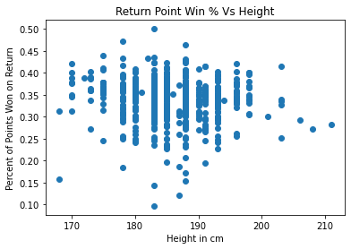

```python
#plotting 7th plot height vs return point win percent
fig7,ax7 = plt.subplots()
ax7.scatter(playerStats['heights'],playerStats['winReturnPercents'])
ax7.set_xlabel('Height in cm')
ax7.set_ylabel('Percent of Points Won on Return')
ax7.set_title('Return Point Win % Vs Height')
fig7.show()
```

The final plot of return statistics once again seems to suggest no relation with height. There might be a sligth negative relation but not very strong. Once again there is a main block of percent points won that contain most of the players and then there are some outliers above and below, the range that contains most for all heights is around 25% to 40%. The taller players seem to be at the lower end of this range with none towards the higher end. This leads me to think there might still be a slight negative relation between return point percent won and height. It is suprising that there did not seem to be a relation with height and any of the return statistics on first look. Now we will check for sure running hypothesis tests using the stats model library.

# Hypothesis Testing

Now I am going to use the statistical model library to make linear regressions for the data and run a hypothesis test. First I am assuming the relation between these statistics and heights are linear. I think this is true in the scope of professional players, who have a higher cut off for height then the human population, if you extended this to a wider range of heights it might not be linear. Nothing in the plot above suggested it should be a different order polynomial to me. I think a linear relationship works.

Reminder of the assumptions of a linear regression  
1.That a linear relationship exists  
2.Independence of residuals  
3.Constant Variance of residuals (this is known as 'Homoscedasticity')  
4.That the residuals are normally distributed (this is known as 'Normality')

To do this I will being using the statisticsal model library, since they have many more built in features for hypothesis testing then other machine learning algoritms. I will be using the OLS linear regression. OLS means ordinary least squares which refers to the loss function the regression is using. I think least squares is on of the better loss functions so that is why I chose to use this version. If you want to learn more about the library or this specific regression you can use the links below.  
Statistical Model: https://www.statsmodels.org/dev/user-guide.html  
More on the specific regression: https://www.statsmodels.org/dev/generated/statsmodels.regression.linear_model.OLS.html

```python
ind = stats.add_constant(playerStats['heights'])
dep = playerStats['firstPercents']
firstPercentreg = stats.regression.linear_model.OLS(dep,ind).fit()
print('firstPercent = '  +str(firstPercentreg.params[1]) +'*height' + " + " + str(firstPercentreg.params[0]))
print(firstPercentreg.pvalues)
```

```
firstPercent = 0.0006766624043443335*height + 0.481698421255832
const      1.485001e-14
heights    3.987426e-02
dtype: float64
```

It seems that my opinion at first glance of the scatter plot was incorrect. The p-value is about .04 which is less than are designated .05 cutoff, so there is enough evidence to reject the null hypothesis that there is no relationship between height and first serve percentage. This is why it is important to actually look at the numbers and not just see the plot and make your decision there. My prediction was that there was no relation between height and first serve percent so maybe I had some confirmation bias when looking at the plot, while the hypothesis tells a different story. Based on the regression parameters there seems to be a slight positive relationship between height and first serve percentage. This is once again contrary to my prediction. I thought that first serve percent in would be pretty universal but the quality of serves being hit would vary. It appears that this is not the case and we reject there is no relationship.

```python
dep = playerStats['firstWRates']
firstServeWRate = stats.regression.linear_model.OLS(dep,ind).fit()
print('firstWRate = '  +str(firstServeWRate.params[1]) +'*height' + " + " + str(firstServeWRate.params[0]))
print(firstServeWRate.pvalues)
```

```
firstWRate = 0.003625859441919382*height + 0.0024886062098242734
const      9.749836e-01
heights    1.735586e-16
dtype: float64
```

On the first serve win rate it appears my original prediction and first impression on the plot were correct. The p-value as seen above is much smaller than .05 so there is enough evidence to reject the null hypothesis, that there is no relation between height and first serve win rate. According to the regression there is a slight positive relationship between height and first serve win rate. This makes sense from experience watching tennis, since it seems that taller people had bigger serves and got alot more easy points while serving. It was important to check since these ideas could have been through bias where I only remember the tall players that serve bigger. It seems the stereotype that tall people have good first servers has basis in the statistics.

```python
dep = playerStats['secWRates']
secondServeWRate = stats.regression.linear_model.OLS(dep,ind).fit()
print('secWRate = '  +str(secondServeWRate.params[1]) +'*height' + " + " + str(secondServeWRate.params[0]))
print(secondServeWRate.pvalues)
```

```
secWRate = 0.000552050479880718*height + 0.3739700499101283
const      0.000001
heights    0.180336
dtype: float64
```

The p-value is .18 which is greater than .05 so there is not enough evidence to reject the null hypothesis that there is no relation between height and second serve win rate. This is in line with my first thoughts after seeing the plot above, but it is still opposite to my original prediction. It is interesting to note that height seems to help players win first serves but some how not second. I wonder what could be causing the difference there. Possibly it is second serves are normally spin serves and height doesn't help there, while first serves are normally flatter.

```python
dep = playerStats['aceRate']
aceReg = stats.regression.linear_model.OLS(dep,ind).fit()
print('aceRate = '  +str(aceReg.params[1]) +'*height' + " + " + str(aceReg.params[0]))
print(aceReg.pvalues)
```

```
aceRate = 0.0031524256509111977*height + -0.522457320540869
const      7.176062e-38
heights    1.124874e-45
dtype: float64
```

The p-value is the smallest so far and is well below .05, so there is enough evidence to reject the null hypothesis that there is no relation between height and ace rate. This p-value is the smallest so far and shows what was observed above that the ace plot had a much stronger relation then the other plots. This regression suggests that the ace rate of players has a positive relation with height. Whihc means that players that are taller get more free points off of their serves. This makes sense with what is observed while watching tennis. Taller players normally seem to have big serves and are capable of getting sharper angles. This would be a big advantage because they will be much harder to pressure on serve.

```python
dep = playerStats['bpChances']
bpChanceReg = stats.regression.linear_model.OLS(dep,ind).fit()
print('breakPointChances = '  + str(bpChanceReg.params[1]) + '*height' + " + " + str(bpChanceReg.params[0]))
print(bpChanceReg.pvalues)
```

```
breakPointChances = -0.021531819129611617*height + 9.675229623173028
const      0.000514
heights    0.149280
dtype: float64
```

This is the first hypothesis test for return statistics. The p-value is above .05 so there is not enough evidence to reject the null hypothesis that there is no relationship between hight and average break point chances. This is once again not what I initially predicted, but fits with the observations of the scatter plot. This suprised me because tall people are normally thought to be worse returns. All my predictions were just from my experience watching tennis, and tall players matches always seem to me service battles and almost never any breaks.This is why it is important to let the numbers speak when it comes to sports and not just assume your observations were right. It is worth noting that in the regression there is a negative slope with the height even if the coefficient is labeled as not significant.

```python
dep = playerStats['bpWinPer']
bpWinReg = stats.regression.linear_model.OLS(dep,ind).fit()
print('bpWinPercent = '  +str(bpWinReg.params[1]) +'*height' + " + " + str(bpWinReg.params[0]))
print(bpWinReg.pvalues)
```

```
bpWinPercent = -0.0005216110551771378*height + 0.45918868357494674
const      0.016848
heights    0.613198
dtype: float64
```

The p-value here is much larger than .05 so there is no enough evidence to reject the null hypothesis that there is no relation between height and break point win percent. This is once again not what I predicted based on my experience with tennis, but is in line with what I observed in the scatter plot above. This regression line has a very slight slope so does not change its prediction very much on break point win percent based on height. Height so far is not signifcant when it come to return statistics.

```python
dep = playerStats['winReturnPercents']
returnWinRate = stats.regression.linear_model.OLS(dep,ind).fit()
print('ReturnWinRate = '  +str(returnWinRate.params[1]) +'*height' + " + " + str(returnWinRate.params[0]))
print(returnWinRate.pvalues)
```

```
ReturnWinRate = -0.0007043533409134852*height + 0.47193386897238343
const      4.097389e-15
heights    2.564932e-02
dtype: float64
```

The p-value above is below .05 so there is enough evidence to reject the null hypothesis that there is no relation between height and return point win percent. This is in line with my original predictions, but not with my guess after oberving the scatter plot. According to the regression there is a a very slight negative relation with height and return win percent. It is interesting that the p-value was only significant for return point win percentage. I would have thought return point win percentage would have been very closely related with break point chances and break point win percent. I thought this because to get break points you need to win at least 3 points, and the percent of break points won I thought would have been very similar to percent of return points won. It is interesting to me that only one has a significant p-value and not all three having the same.

It is worth noting that all the regression with serve statistics had positive slopes with height and all the return statistics had negative slopes with repsect to height. Based on the hypothesis testing there does seem to be a statistical basis to the idea tall players are better servers and worse returners, even if it is not sayable for every individual statistic.

# Win Rate

Now that we have looked at the relation of height and certain serve and return statistics and ovserved that there tends to be a positive relation with height and serving, and a negative relation with height and returning. I am going to look at whether height has a relationship with winning and if the trade off of a better serve for a worse return is worth it. In the end having a good serve does nothing for you if you can't win the match. In order to win a tennis match you must be able to both win on return and serve.

Lets first look at a scatter plot with height and win rate.

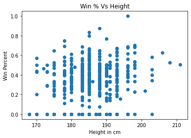

```python
#plotting 8th plot win percent vs height
fig8,ax8 = plt.subplots()
ax8.scatter(playerStats['heights'],playerStats['WinRate'])
ax8.set_xlabel('Height in cm')
ax8.set_ylabel('Win Percent')
ax8.set_title('Win % Vs Height')
fig8.show()
```

On first appearance there does not seem to be any relation to me, but I was wrong several times on first appearances in the last plots. There once again seems to be one main body of points and then some outlies above and below. It seems like a fairly neutral plot to me, no strong negative or positive patterns that I see.

Now lets look at the regression and run a hypothesis test to make sure.

```python
dep = playerStats['WinRate']
WinRateReg = stats.regression.linear_model.OLS(dep,ind).fit()
print('WinRate = '  +str(WinRateReg.params[1]) +'*height' + " + " + str(WinRateReg.params[0]))
print(WinRateReg.pvalues)
```

```
WinRate = 0.005759626921112509*height + -0.7839006938188346
const      0.002911
heights    0.000051
dtype: float64
```

The pvalue is below .05 so there is enough evidence to reject the null hypothesis that there is no relationship between win rate and height. The regression suggest that there is a positive relation between height and win rate. This is suprising to me I did not think that height would really be that helpful towards winning, except maybe to a cut off in the lower heights. But according to this height is better and helps you win tennis matches. This suprises me because most of the players considered the best to ever play are not very tall for a professional tennis player. The big three are Federer (185cm), Nadal (185 cm), and Djokovic (188cm). These three players all seem to be slightly below average height but are three of the most dominant players in tennis. Thinking about it now they are probably outliers and not representative of the entire professional tour or players of their height. In general it appears that the taller you get the higher win rate you have on the ATP tour. This shows once again why it is important to let the data speak for itself and not personal observations. People are most likely going to remember the best players they see like a Federer and forget other players the same height who aren't as good. Then you will think that people Federers height are the best height for tennis. This could be one explanation to why I thought this way before looking at the numbers.

# Conclusion

It appears that the stereotype that tall players are good servers are and bad returns have a basis in the data on the ATP tour over the last couple of years. While not all the hypothesis tests showed that height was significant, there was at least one for both serving and returning that did. It appears that height has a positive relation with first server percent in, first serves percent won, and ace rate, while having a negative relation with total return points percent won. Based on the hypothesis tests I am unable to make a conclusion for any relation between height and break point chances and break point win percentage. It would be interesting to look deeper into why that is. If you are winning less return points you would think you would average less break point chances. Maybe taller people are having a lot more return games where they only win 1 or even no points, while other players more consistantly get 2 points but not to a break point. Then they both get a similar number of games where they make it to break point and actually win. This could be one explanation for this apparent inconsistency. It also appears that height has a positive relationship with winning. Taller players tend to have a higher win percent on the ATP tour. This means the the tradeoffs in of being tall in the game of tennis are worth it overall. This is good to know especially when it comes to looking for rising talent, you might what to focus on taller players even if at the moment they are slightly worse because they have a untrainable feature that helps increase winning. Therefore if you can catch them up skill wise they could possibly be a better player. This of course is not a certain thing as we have addressed certaion outliers like Federer, Djokovic, and Nadal. Clearly height should not be the only factor taken into account but it should be thought about be the tennis community when looking for young up and comers. Another important thing to take away for this tutorial is the importance to let the numbers talk for you and not bring in any of your prebelieved importance. As seen during my hypothesis test, my initial prediction on several of the statistics was wrong. This empahize why, especially in sports, to not make conclusions on just your observations because many times you may be wrong.